# Understanding GM control strategy effects

# Summary of findings

As detailed in the following:

# Read and clean the data

Clean up all the NetLogo variable name weirdness with `janitor::clean_names()`, along with a couple of other tidy ups to simplify names. We also convert some variables to factors and consistently order them from lower to higher ‘control-effort’ to improve the visualizations.

```r
setwd("~/Documents/code/wasps/experiments")
wasps <- read.csv(
  "wasps GRID-RELEASE-EXPERIMENT-FINAL-table.csv", skip = 6) %>%
  clean_names() %>%
  rename(run_number = x_run_number, t = x_step,
         strategy = spatial_or_temporal,
         per_site = colonies_per_site) %>%
  mutate(total_wild = total_pop - total_gm - total_sterile,
         program_duration = as.factor(program_duration),
         period = factor(# as.character(periodicity),
                         periodicity, levels = c(1, 2, 4, 0),
                         labels = c("1", "2", "4", "Once")),
         grid_resolution = factor(# as.character(grid_resolution),
                                  grid_resolution, levels = c(5, 2, 1),
                                  labels = c("5", "2", "1")),
         per_site = factor(per_site,
                           levels = c(20, 40, 80, 200, 500)),
         strat = str_c(strategy, program_duration)) %>%
  select(-grid_releases, -periodicity, -percentile_selector,
         -(use_seed:monitor_area))  # get rid of a bunch of stuff we don't use
```

## Standardise population figures to start populations

This seems worth doing for simplicity’s sake.

```r
start_pops <- wasps %>%
  filter(t == 0) %>%
  select(run_number, total_pop, total_wild, total_gm) %>%
  rename(pop_0 = total_pop,
         wild_0 = total_wild,
         gm_0 = total_gm)

wasps <- wasps %>%
  merge(start_pops, all.x = TRUE) %>%
  mutate(pop_t = total_pop / pop_0,
         wild_t = total_wild / wild_0,
         gm_t = total_gm / gm_0)
```

# Eradication success

First we tag scenarios where eradication has occurred. These are any that end ‘prematurely’ before the full 100 year run time elapsed.

```r
end_time <- wasps %>%
  group_by(run_number) %>%
  summarise(max_t = max(t))

wasps <- wasps %>%
  merge(end_time) %>%
  mutate(eradication = max_t < 100)
```

Now we can make a (complicated!) plot showing eradication success rate relative to different control program settings.

```
## 'grid_resolution'. You can override using the `.groups` argument.
```

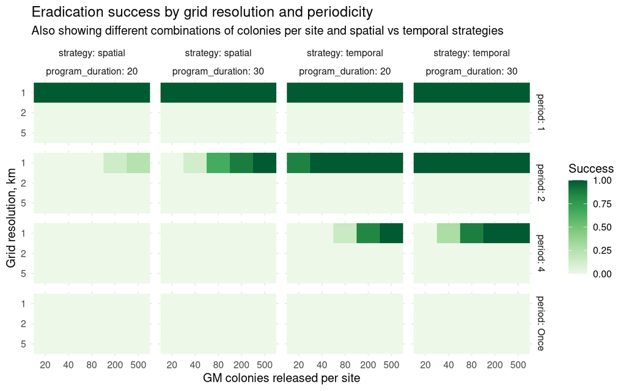

```r
wasps %>%
  select(eradication, strategy, per_site, program_duration,
         grid_resolution, period) %>%
  group_by(strategy, per_site, program_duration,
           grid_resolution, period) %>%
  summarise(success = sum(eradication) / n()) %>%
  ggplot() +
    geom_tile(aes(x = per_site, y = grid_resolution, fill = success)) +
    scale_fill_distiller(palette = "Greens", direction = 1) +
    facet_grid(period ~ strategy + program_duration,
               labeller = label_both) +
    ggtitle("Eradication success by grid resolution and periodicity",
            subtitle = "Also showing different combinations of colonies per site and spatial vs temporal strategies") +
    labs(x = "GM colonies released per site", y = "Grid resolution, km", fill = "Success") +
  theme_minimal()
```

```r
# +
#   theme(text = element_text(size = 6, family = "sans"))

# ggsave("control-strategy-success/fig5-control-strategy-success.pdf",
#        width = 150, height = 105, units = "mm", dpi = 600)
```

**Note** It isn’t clear which particular combinations of variables should be used in the individual panels vs those conditioning which scenarios are included in each panel. I have ordered all variables and factors so that ‘more effort’ is up and right both within panels, and (to the extent possible) also in the arrangement of panels.

There are two broad strategies in these results, where the interpretation of the `period` setting is slightly different:

- `spatial` (the two leftmost columns) where `period` denotes that the chosen grid of release sites is activated every year, but only at every nth site; or
- `temporal` (the two rightmost columns) where every site in the grid of release sites is activated every nth year, with n the `period`.

Additionally, each strategy may be in place for either 20 or 30 years (`program_duration`). **Note** that `periodicity == 'None'` in both cases is a ‘release-once-and-forget’ strategy, which never achieves eradication in either case, and where `period` and `program_duration` settings are irrelevant.

From the above plots, overall the `temporal` strategies are more successful. However in both cases, eradication only occur when `grid_resolution` is 1, i.e. a very dense network of release sites is required. `spatial` strategies relatively rarely achieve eradication when the `period` is other than 1 (i.e. every site). This suggests that the key determinant of eradication is ‘flooding’ the entire landscape regularly, which prevents wild populations ‘escaping’ from GM wasps.

In the `temporal` strategies there is an increased chance of eradication when more colonies are released per site, such that even if releases only occur every 4 years eradication is still possible at high levels of releases. Note that these are very high levels of release — close to half the maximum habitat capacity of wasps!

The overall picture is only marginally affected by control program duration. Some details of the differences here are discussed in the section Sensitivity of success to program duration below.

# Time series visualizations

To try to understand better what’s going on, we now look at time series evolution of the total wild wasp population relative to the initial population.

```r
wasps$period <- fct_rev(wasps$period)
wasps$grid_resolution <- fct_rev(wasps$grid_resolution)
```

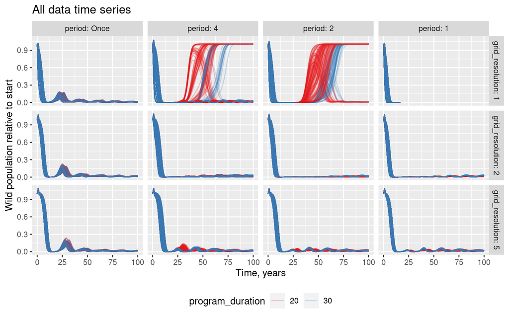

```r
ggplot(wasps) +
  geom_line(aes(x = t, y = wild_t, colour = program_duration,
                group = run_number), alpha = 0.25) +
  scale_colour_brewer(palette = "Set1") +
  facet_grid(grid_resolution ~ period, labeller = label_both) +
  ggtitle("All data time series") +
  labs(x = "Time, years", y = "Wild population relative to start") +
  theme(legend.position = "bottom")
```

Using all the data as above makes it hard to discern specific effects of different scenario parameters. So below, we consider some subsets of the data to try to better understand the dynamics.

## Sensitivity of success to program duration

First we revisit the effect of the control program duration on success. This is a story of the *sensitive dependence of success on when a control program is stopped*.

The confusing times series in the middle two panels of the top row of the ‘all data’ time series plots, show how sensitively dependent eventual eradication success might be on small numbers of surviving wild and GM wasps in much reduced populations. To examine this, here is a closer look at the relevant plots, subdivided by spatial and temporal strategy cases (which otherwise greatly confuse the picture).

First, split the data by `spatial` vs `temporal` strategy.

```r
wasps_s <- wasps %>%
  filter(strategy == "spatial")
wasps_t <- wasps %>%
  filter(strategy == "temporal")
```

### Temporal strategy: wild wasp recovery is rare but unpredictable

**Remember**, this is with reference only to those scenario settings where eradication is *almost* achieved, i.e. when `grid_resolution == 1` and `period != 1`.

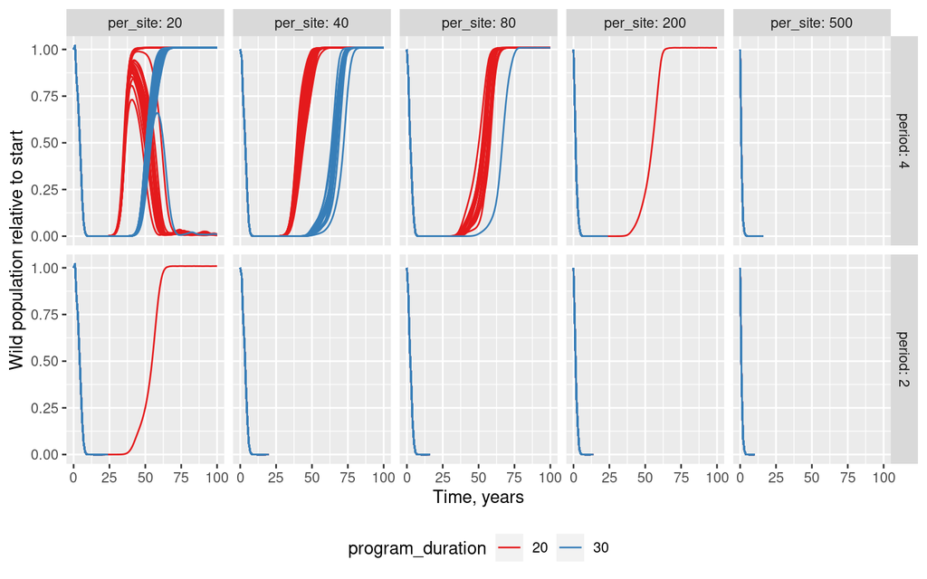

```r
wasps_t %>%
  filter(period %in% c("2", "4"), grid_resolution == "1") %>%
  ggplot() +
    geom_line(aes(x = t, y = wild_t, colour = program_duration,
                  group = run_number)) +
    scale_colour_brewer(palette = "Set1") +
    facet_grid(period ~ per_site, labeller = label_both) +
    labs(x = "Time, years", y = "Wild population relative to start") +
    theme(legend.position = "bottom")
```

`per_site` release numbers affect the initial rate of population fall (this is clearer in the next section) but also act as a control on the probability of dramatic recovery in wild populations. This recovery also depends on the program duration.

### Spatial strategy: wild wasp recovery is commonplace

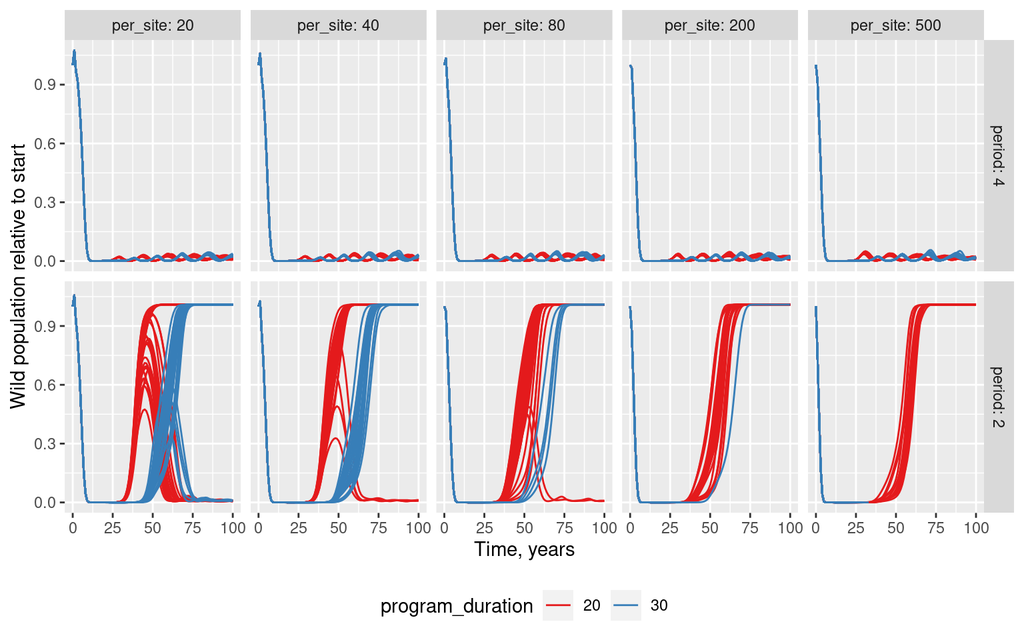

```r
wasps_s %>%
  filter(period %in% c("2", "4"), grid_resolution == "1") %>%
  ggplot() +
    geom_line(aes(x = t, y = wild_t, colour = program_duration,
                  group = run_number)) +
    scale_colour_brewer(palette = "Set1") +
    facet_grid(period ~ per_site, labeller = label_both) +
    labs(x = "Time, years", y = "Wild population relative to start") +
    theme(legend.position = "bottom")
```

In the case of the spatial strategy (where releases are made every year, but only at every nth site) the results are easier to parse, but again, show how sensitive eventual success is to ‘knowing when to stop’. The more intense `period == 2` scenarios ultimately see full recovery of the wild wasp population in almost all cases, while the less intense `period == 4` scenarios settle into a low wasp population long term equilibrium! A key management challenge would seem to be an ability to distinguish the situations in the top row of this plot from those in the bottom, i.e. detecting if there are still GM wasps present in small populations.

The general conclusion from both these sets of results is that the worst possible outcome is one where a program thought to have been successful is abandoned too soon. The only way to avoid this outcome would seem to be to continue with a program long after the point where it seems to have already succeeded, which would involve a situation where the vast majority of wasps in the population would be those being released as part of the control program!

## Effects of releasing more GM wasps at each site

Considering only `periodicity == 'None'` release-and-forget strategies, over their first 50 years, we can see the impact of the numbers of GM wasps released on the speed of convergence on the long term equilibrium.

```r
wasps$grid_resolution <- fct_rev(wasps$grid_resolution)
```

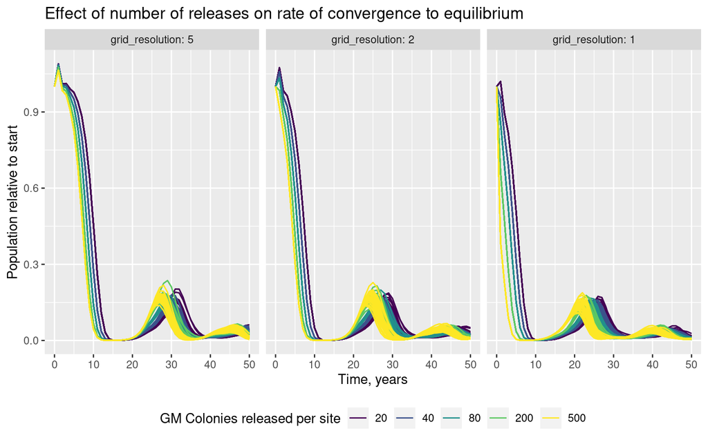

```r
wasps %>% filter(strategy == "temporal", period == "Once", t <= 50) %>%
  ggplot() +
    geom_line(aes(x = t, y = wild_t, colour = as.factor(per_site),
                  group = run_number)) +
    scale_colour_viridis_d() +
    facet_wrap(~ grid_resolution, scales = "free_x", labeller = label_both) +
    ggtitle('Effect of number of releases on rate of convergence to equilibrium') +
    labs(x = "Time, years", y = "Population relative to start",
         colour = "GM Colonies released per site") +
    theme(legend.position = "bottom")
```

Similarly, in eradication scenarios, releasing more wasps accelerates the effect.

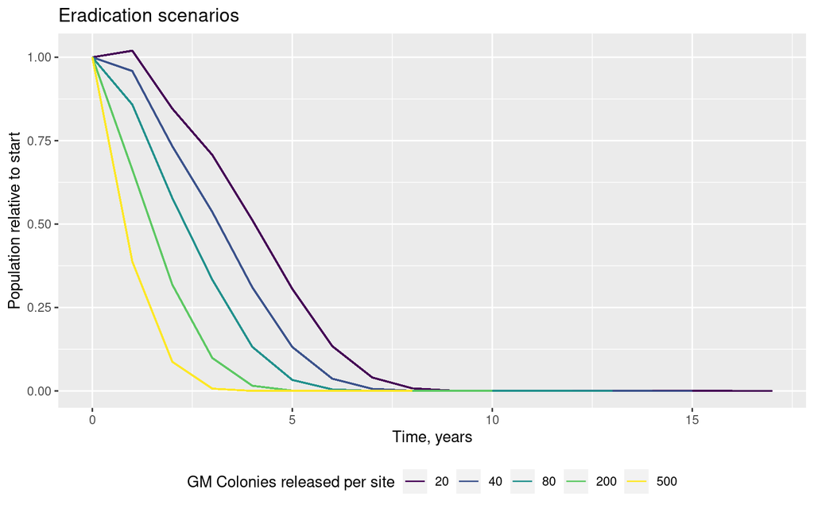

```r
wasps %>% filter(strategy == "temporal", period == "1",
                 grid_resolution == "1") %>%
  ggplot() +
    geom_line(aes(x = t, y = wild_t, colour = as.factor(per_site),
                  group = run_number)) +
    scale_colour_viridis_d() +
    ggtitle('Eradication scenarios') +
    labs(x = "Time, years", y = "Population relative to start",
         colour = "GM Colonies released per site") +
    theme(legend.position = "bottom")
```

The time to eradication is also reduced by releasing more wasps. Again, keep in mind all these scenarios involve releasing vast numbers of GM wasps over wide areas!

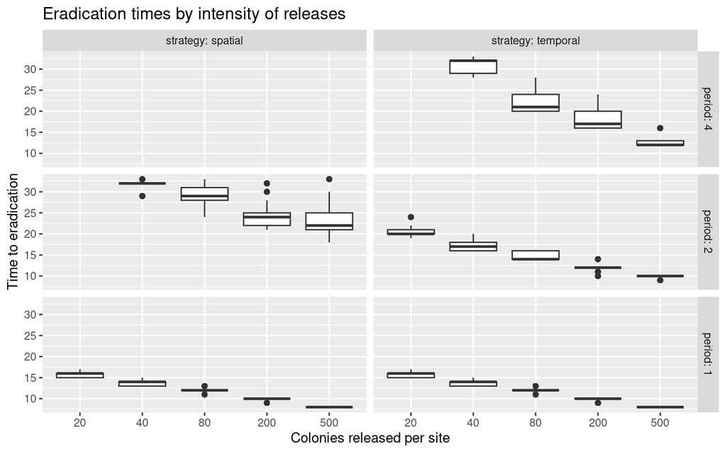

```r
wasps %>% filter(eradication == TRUE) %>%
  select(per_site, max_t, period, strategy) %>%
  mutate(per_site = as.factor(per_site)) %>%
  ggplot() +
    geom_boxplot(aes(x = per_site, y = max_t, group = per_site)) +
    facet_grid(period ~ strategy, labeller = label_both) +
    labs(x = "Colonies released per site", y = "Time to eradication",
         title = "Eradication times by intensity of releases")
```